# Homework_2

2024-12-09

View(weather)

## Task 1

```
## # A tibble: 9 × 2
##   month cold_days
##   <int>     <int>
## 1     1        32
## 2     2        29
## 3     3        32
## 4     4        22
## 5     5        12
## 6     9         3
## 7    10        12
## 8    11        28
## 9    12        28
```

```
## # A tibble: 1 × 1
##   total_missing
##           <int>
## 1          8255
```

```
## # A tibble: 1 × 20
##   total_missing_dep_time  year month   day dep_time sched_dep_time dep_delay
##                    <int> <int> <int> <int>    <int>          <int>     <int>
## 1                      0     0     0     0      521              0       521
## # ℹ 13 more variables: arr_time <int>, sched_arr_time <int>, arr_delay <int>,
## #   carrier <int>, flight <int>, tailnum <int>, origin <int>, dest <int>,
## #   air_time <int>, distance <int>, hour <int>, minute <int>, time_hour <int>
```

## Task 2

```
## # A tibble: 1 × 4
##   total_missing_dep_time missing_sched_dep_time missing_arr_time
##                    <int>                  <int>            <int>
## 1                    521                      0              521
## # ℹ 1 more variable: missing_air_time <int>
```

## Task 3 - a

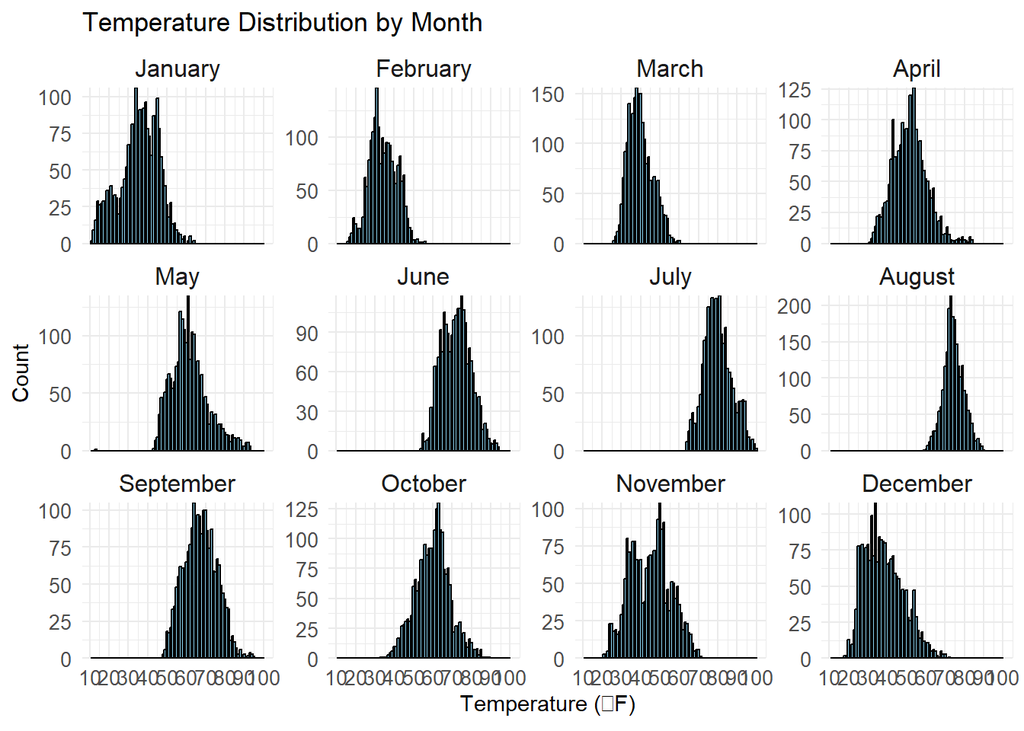

## Task 3 - b

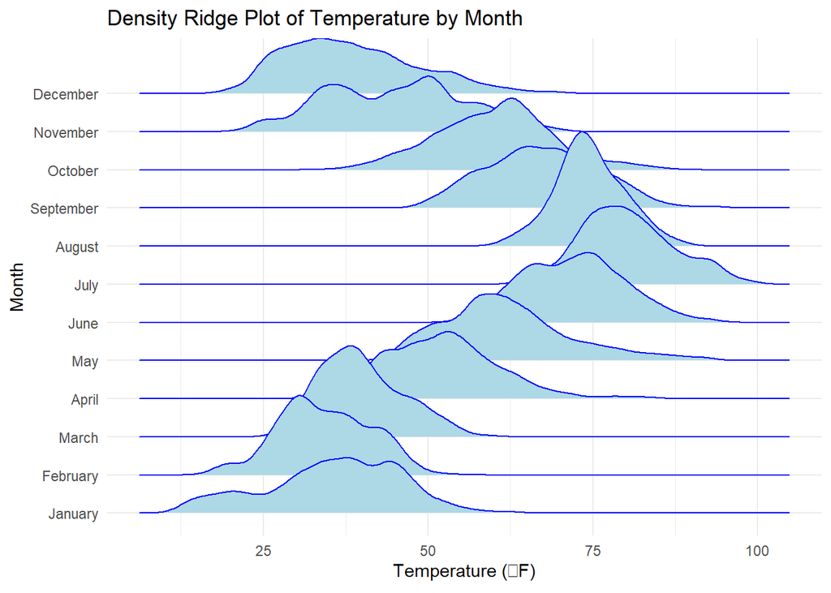

## Task 3 - c

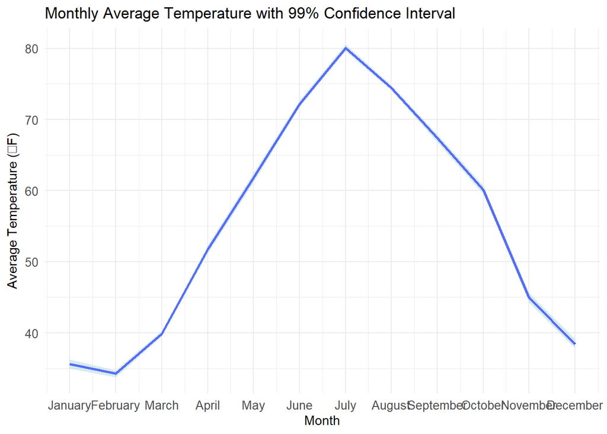

### We sat down at the beginning and divided up the tasks. The first thing we did was set up a Git repository so that we could easily collaborate and continuously track each other’s progress. We organized the tasks so that Fabian took on tasks 1 and 2, while Samuel handled tasks 3-5. This clear division helped us focus and avoid overlapping efforts. After completing our initial assignments, we held a short meeting to discuss the status and share updates on our progress. This check-in proved beneficial, as it highlighted some areas that needed further refinement. Although a few items were still incomplete, we felt that we were moving in the right direction and understood what remained to be done. To ensure the quality of each other’s work, we decided that Fabian would review and make corrections to Samuel’s tasks, and vice versa. This mutual review process not only helped catch errors but also facilitated a better understanding of each other’s approach. By the end of the session, we felt more confident about our progress and looked forward to wrapping up the remaining tasks.